# Lab10

### 19BCE1560

### 11th October, 2021

## Index

Click to go to the respective Question  
1. Question 1  
2. Question 2  
3. Question 3  
4. Question 4  
5. Question 5

## Question 1

Q. For the Insurance data set in MASS library. Identify column types Print the summary statistics of the columns.  
A.

```r
library(MASS)
data(Insurance)
head(Insurance,5)
```

```
##   District  Group   Age Holders Claims
## 1        1    <1l   <25     197     38
## 2        1    <1l 25-29     264     35
## 3        1    <1l 30-35     246     20
## 4        1    <1l   >35    1680    156
## 5        1 1-1.5l   <25     284     63
```

Types of each column

```r
str(Insurance)
```

```
## 'data.frame':    64 obs. of  5 variables:
##  $ District: Factor w/ 4 levels "1","2","3","4": 1 1 1 1 1 1 1 1 1 1 ...
##  $ Group   : Ord.factor w/ 4 levels "<1l"<"1-1.5l"<..: 1 1 1 1 2 2 2 2 3 3 ...
##  $ Age     : Ord.factor w/ 4 levels "<25"<"25-29"<..: 1 2 3 4 1 2 3 4 1 2 ...
##  $ Holders : int  197 264 246 1680 284 536 696 3582 133 286 ...
##  $ Claims  : int  38 35 20 156 63 84 89 400 19 52 ...
```

We see that District, Group and Age are categorical data types. Holders and Claims are integer.  
Statistical summary

```r
summary(Insurance)
```

```
##  District    Group       Age        Holders            Claims
##  1:16     <1l   :16   <25  :16   Min.   :   3.00   Min.   :  0.00
##  2:16     1-1.5l:16   25-29:16   1st Qu.:  46.75   1st Qu.:  9.50
##  3:16     1.5-2l:16   30-35:16   Median : 136.00   Median : 22.00
##  4:16     >2l   :16   >35  :16   Mean   : 364.98   Mean   : 49.23
##                                  3rd Qu.: 327.50   3rd Qu.: 55.50
##                                  Max.   :3582.00   Max.   :400.00
```

## Question 2

Q. Calculate the frequency , relative frequency and cumulative frequency for any categorical column and plot the bar chart and pie chart. Write your observations  
A. Let us take the ‘Districts’ column, which is categorical. It is a factor with 4 levels.  
Frequencies:

```r
dist_freq = table(Insurance$District)
dist_freq
```

```
##
##  1  2  3  4
## 16 16 16 16
```

Relative frequencies:

```r
dist_rel_freq = dist_freq/nrow(Insurance)
dist_rel_freq
```

```
##
##    1    2    3    4
## 0.25 0.25 0.25 0.25
```

Cumulative Frequency:

```r
dist_cum_freq = cumsum(dist_freq)
dist_cum_freq
```

```
##  1  2  3  4
## 16 32 48 64
```

Bar plot of frequencies:

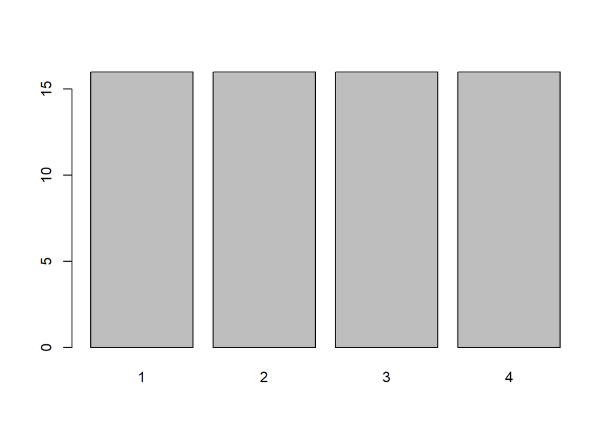

```r
barplot(dist_freq)
```

Bar plot of cumulative frequencies:

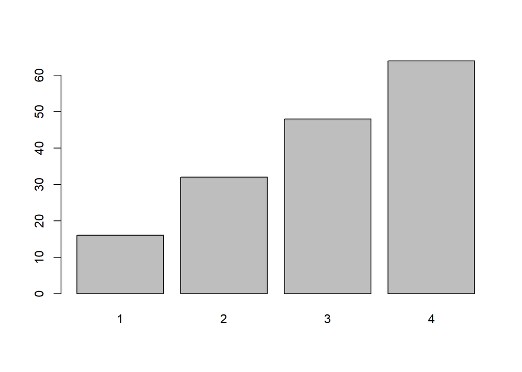

```r
barplot(dist_cum_freq)
```

Pie chart of relative frequencies:

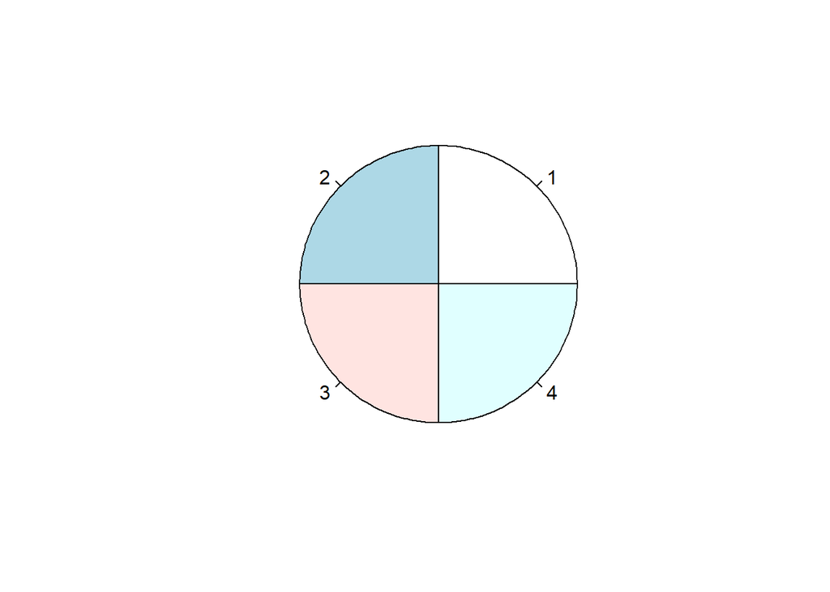

```r
pie(dist_rel_freq)
```

From the plots and frequencies listed above, we see that the categories or districts for the entries are equally distributed.

## Question 3

Q. For one of the numerical columns split them into sequences. There should be at least 5 intervals. Calculate the frequency of values occurring in each interval and plot a bar plot.  
A. We shall use the ‘Holders’ column.

```r
holders=Insurance$Holders
range(holders)
```

```
## [1]    3 3582
```

We have values from 3 to 3582. So, let us break it into 5 intervals with each interval having a length of 716 because (3582-3)/5 = 715.8 and we take one higher than the pper limit 3582.

```r
breaks=seq(3,3583, by=716)
breaks
```

```
## [1]    3  719 1435 2151 2867 3583
```

Now we break the columnvalues into these intervals

```r
holders.cut = cut(holders,breaks,right=FALSE)
```

Frequency of each interval

```r
freq=table(holders.cut)
freq
```

```
## holders.cut
##             [3,719)      [719,1.44e+03) [1.44e+03,2.15e+03) [2.15e+03,2.87e+03)
##                  56                   3                   3                   1
## [2.87e+03,3.58e+03)
##                   1
```

Frequency plot of each interval

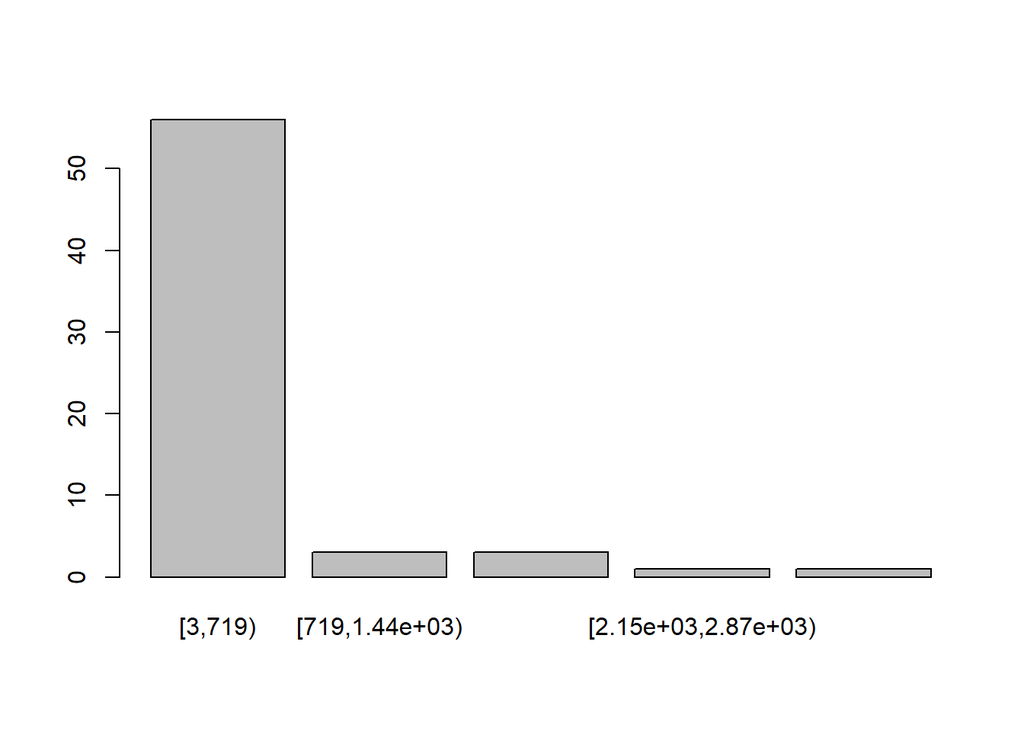

```r
barplot(freq)
```

## Question 4

Q. Create a scatter line plot for the cumulative frequency of the numerical column split in question 3.  
A.

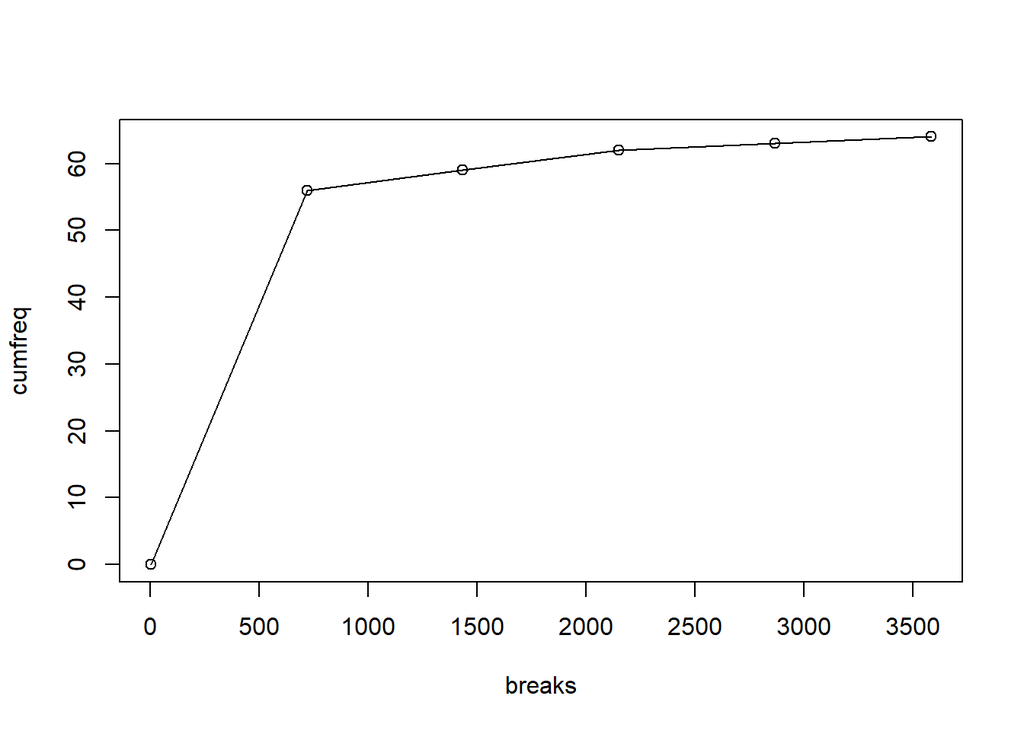

```r
cumfreq = cumsum(freq)
cumfreq=c(0,cumfreq)
plot(breaks,cumfreq)
lines(breaks,cumfreq)
```

## Question 5

Q. Draw the scatter plot between two numerical columns and infer the correlation between them.  
A. The columns we will use are Holders and Claims.

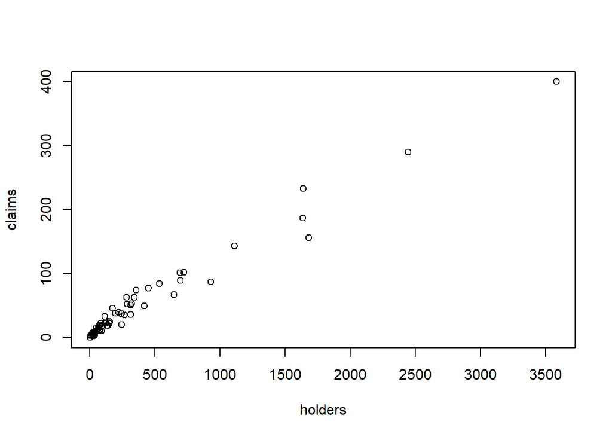

```r
holders=Insurance$Holders
claims=Insurance$Claims
plot(holders,claims)
```

We can see that as the Holders’ axis value increases, so does Claims’. This is positively correlated.